# COVID-19 Mortality Prediction Model

**By Seungmin Oh, Fall 2022**

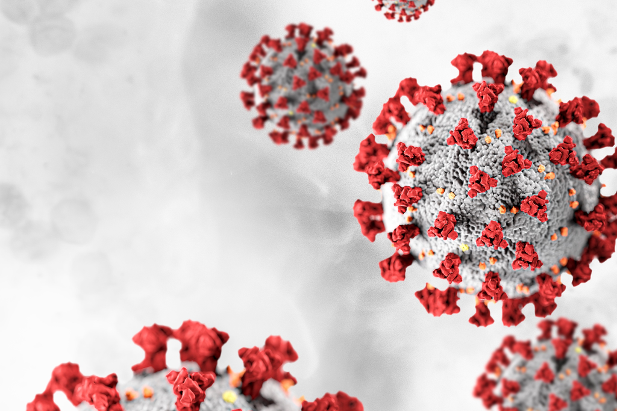

## Table of Contents:

1. Introduction
2. Data Collection
3. Data Management/Processing
4. Exploratory Data Analysis
5. Hypothesis Testing
6. Training the Machine Learning Model
7. Conclusion

## Part 1 : Introduction

### Motivation

In the early 2020, we encountered something most of us had never thought of experiencing in our lifetime: **A global pandemic**.  
In March 2020, I remember being in a classroom in high school as a senior, hearing the announcement and being happy to go home early, not knowing what was about to happen next. Most teachers and students had expected to be back in school within a couple weeks, which turned out to be wrong. Although the virus started in late 2019, most people did not know or care about it until the lockdown started. In the state of Maryland, Governor Hogan ordered a lockdown on March 23rd, 2020 and it lasted until June 15th, 2021. Now, we're in 2022 but I'm quite certain that we all agree on how much impact this virus has had in people's lives across the globe.  
Therefore, for my final project of the intro data science course, I want to explore the factors that can affect the mortaility rate of covid and create a model that predicts the mortality rate of a covid patients based on their health conditions.

### More Info

I'm sure you're already familiar with the virus, but in case you want to read up more about it before getting into the analysis, here are some links:  
[COVID-19 Wikipedia Page](https://en.wikipedia.org/wiki/COVID-19)  
[CDC Symptoms Page](https://www.cdc.gov/coronavirus/2019-ncov/symptoms-testing/symptoms.html)  
[CDC Info Page](https://www.cdc.gov/coronavirus/2019-ncov/index.html)

### Importing Necessary Tools

```python
# importing libraries needed for the project
import pandas as pd
import numpy as np
import matplotlib.pyplot as plt
import seaborn as sns
import itertools

from sklearn.model_selection import KFold
from sklearn.model_selection import cross_val_score
from sklearn.linear_model import LogisticRegression
from statistics import mean
from sklearn.preprocessing import MinMaxScaler
from imblearn.under_sampling import RandomUnderSampler
from sklearn.model_selection import GridSearchCV
from sklearn.ensemble import RandomForestClassifier
from scipy.stats import pearsonr
```

## Part 2 : Data Collection

The dataset was obtained from: https://www.kaggle.com/datasets/meirnizri/covid19-dataset.  
According to Kaggle, this is a covid dataset provided by the Mexican government and contains information about approximately 1 million patients. The columns consist of underlying health conditions of a patient, whether (and when) they died, age, sex, and more. The dataset was last updated in November, 2022.

```python
# reading the dataset and printing the first 5 rows
df = pd.read_csv("/Users/seungminoh/repos/CMSC320-Final-Project/Covid Data.csv")
df.head()
```

|  | USMER | MEDICAL_UNIT | SEX | PATIENT_TYPE | DATE_DIED | INTUBED | PNEUMONIA | AGE | PREGNANT | DIABETES | ... | ASTHMA | INMSUPR | HIPERTENSION | OTHER_DISEASE | CARDIOVASCULAR | OBESITY | RENAL_CHRONIC | TOBACCO | CLASIFFICATION_FINAL | ICU |
| --- | --- | --- | --- | --- | --- | --- | --- | --- | --- | --- | --- | --- | --- | --- | --- | --- | --- | --- | --- | --- | --- |
| 0 | 2 | 1 | 1 | 1 | 03/05/2020 | 97 | 1 | 65 | 2 | 2 | ... | 2 | 2 | 1 | 2 | 2 | 2 | 2 | 2 | 3 | 97 |
| 1 | 2 | 1 | 2 | 1 | 03/06/2020 | 97 | 1 | 72 | 97 | 2 | ... | 2 | 2 | 1 | 2 | 2 | 1 | 1 | 2 | 5 | 97 |
| 2 | 2 | 1 | 2 | 2 | 09/06/2020 | 1 | 2 | 55 | 97 | 1 | ... | 2 | 2 | 2 | 2 | 2 | 2 | 2 | 2 | 3 | 2 |
| 3 | 2 | 1 | 1 | 1 | 12/06/2020 | 97 | 2 | 53 | 2 | 2 | ... | 2 | 2 | 2 | 2 | 2 | 2 | 2 | 2 | 7 | 97 |
| 4 | 2 | 1 | 2 | 1 | 21/06/2020 | 97 | 2 | 68 | 97 | 1 | ... | 2 | 2 | 1 | 2 | 2 | 2 | 2 | 2 | 3 | 97 |

5 rows × 21 columns

```python
# printing the column names to see what columns are available
print(df.columns)
```

```
Index(['USMER', 'MEDICAL_UNIT', 'SEX', 'PATIENT_TYPE', 'DATE_DIED', 'INTUBED',
       'PNEUMONIA', 'AGE', 'PREGNANT', 'DIABETES', 'COPD', 'ASTHMA', 'INMSUPR',
       'HIPERTENSION', 'OTHER_DISEASE', 'CARDIOVASCULAR', 'OBESITY',
       'RENAL_CHRONIC', 'TOBACCO', 'CLASIFFICATION_FINAL', 'ICU'],
      dtype='object')
```

### Clarification of the Columns in the Dataset

- USMER : whether the patient treated medical units of the first, second or third level; 1, 2, 3, respectively.
- medical unit : the medical unit where the patient was treated.
- sex : 1 for female and 2 for male.
- patient type : 1 for patients that returned home, 2 for those who were hospitalized
- date_died : date of death; 9999-99-99 for patients who are still alive.
- copd : whether the patient has chronic obstructive pulmonary disease.
- inmsupr : whether the patient has immunosuppression.
- other disease : whether the patient has other diseases.
- classification_final : covid test results; 1-3 for positive, 4-7 for negative or inconclusive.

For the boolean values, 1 means yes, 2 means no, and 97/99 means unknown.

## Part 3 : Data Management/Processing

Looking at the columns, we can see that there are a few columns that are not necessary for our analysis. Therefore, I will drop those columns.  
First, I will drop **USMER** and **MEDICAL UNIT** because they're related to the medical unit where the patient was treated and that information isn't super relevant for our analysis of the mortality rate based on health conditions.  
In addition, I will drop **OTHER_DISEASE** because it's not clear what other diseases the patients have so it's not very useful. Also, I will drop **CLASSIFICATION_FINAL** (covid test results) since everyone in the dataset is a covid patient, which makes this column not all that relevant.  
Lastly, I will drop **PATIENT_TYPE**, **INTUBED** and **ICU** because I want to focus on health conditions that affect the mortality rate of covid patients. Those three columns are related to the treatment of the patients and not their health conditions so we will drop them.  
Additionally, I see some typos in the column names, so I will fix those as well.

```python
# dropping USMER, MEDICAL_UNIT, and OTHER_DISEASE columns
df.drop(['USMER', 'MEDICAL_UNIT', 'OTHER_DISEASE', 'PATIENT_TYPE', 'INTUBED', 'ICU', \
    'CLASIFFICATION_FINAL'], axis=1, inplace=True)
df.rename(columns = {'HIPERTENSION':'HYPERTENSION', 'INMSUPR':'IMMSUPR'}, inplace = True)
df.head()
```

|  | SEX | DATE_DIED | PNEUMONIA | AGE | PREGNANT | DIABETES | COPD | ASTHMA | IMMSUPR | HYPERTENSION | CARDIOVASCULAR | OBESITY | RENAL_CHRONIC | TOBACCO |
| --- | --- | --- | --- | --- | --- | --- | --- | --- | --- | --- | --- | --- | --- | --- |
| 0 | 1 | 03/05/2020 | 1 | 65 | 2 | 2 | 2 | 2 | 2 | 1 | 2 | 2 | 2 | 2 |
| 1 | 2 | 03/06/2020 | 1 | 72 | 97 | 2 | 2 | 2 | 2 | 1 | 2 | 1 | 1 | 2 |
| 2 | 2 | 09/06/2020 | 2 | 55 | 97 | 1 | 2 | 2 | 2 | 2 | 2 | 2 | 2 | 2 |
| 3 | 1 | 12/06/2020 | 2 | 53 | 2 | 2 | 2 | 2 | 2 | 2 | 2 | 2 | 2 | 2 |
| 4 | 2 | 21/06/2020 | 2 | 68 | 97 | 1 | 2 | 2 | 2 | 1 | 2 | 2 | 2 | 2 |

```python
# replace the values of 1 with 0 and 2 with 1 to make things more intuitive

# columns with boolean values are:
bool_columns = ["SEX", "PNEUMONIA", "PREGNANT", "DIABETES", \
    "COPD", "ASTHMA", "IMMSUPR", "HYPERTENSION", "CARDIOVASCULAR", "OBESITY", \
    "RENAL_CHRONIC", "TOBACCO"]

# replacing the values
for column in bool_columns:
    df[column] = df[column].apply(lambda x : 1 if x == 2 else (0 if x == 1 else x))

# replacing the values in DATE_DIED column and renaming the column
df['DATE_DIED'] = df['DATE_DIED'].apply(lambda x : 0 if x == "9999-99-99" else 1)
df.rename(columns={'DATE_DIED':'DEATH'}, inplace=True)

df.head()
```

|  | SEX | DEATH | PNEUMONIA | AGE | PREGNANT | DIABETES | COPD | ASTHMA | IMMSUPR | HYPERTENSION | CARDIOVASCULAR | OBESITY | RENAL_CHRONIC | TOBACCO |
| --- | --- | --- | --- | --- | --- | --- | --- | --- | --- | --- | --- | --- | --- | --- |
| 0 | 0 | 1 | 0 | 65 | 1 | 1 | 1 | 1 | 1 | 0 | 1 | 1 | 1 | 1 |
| 1 | 1 | 1 | 0 | 72 | 97 | 1 | 1 | 1 | 1 | 0 | 1 | 0 | 0 | 1 |
| 2 | 1 | 1 | 1 | 55 | 97 | 0 | 1 | 1 | 1 | 1 | 1 | 1 | 1 | 1 |
| 3 | 0 | 1 | 1 | 53 | 1 | 1 | 1 | 1 | 1 | 1 | 1 | 1 | 1 | 1 |
| 4 | 1 | 1 | 1 | 68 | 97 | 0 | 1 | 1 | 1 | 0 | 1 | 1 | 1 | 1 |

I will also change the ordering of the column names so that all the columns related to health conditions are to the right and others to the left. Moreover, since the **DEATH** column functions as the target variable in our analysis, I will move it to the far left.

```python
# turning the columns into a list and then inserting the columns in the order we want
cols = list(df)
cols.insert(0, cols.pop(cols.index('DEATH')))
cols.insert(1, cols.pop(cols.index('AGE')))
cols.insert(2, cols.pop(cols.index('SEX')))
cols.insert(3, cols.pop(cols.index('PREGNANT')))
cols.insert(4, cols.pop(cols.index('OBESITY')))
cols.insert(5, cols.pop(cols.index('TOBACCO')))

# reordering the columns
df = df.loc[:, cols]
df.head()
```

|  | DEATH | AGE | SEX | PREGNANT | OBESITY | TOBACCO | PNEUMONIA | DIABETES | COPD | ASTHMA | IMMSUPR | HYPERTENSION | CARDIOVASCULAR | RENAL_CHRONIC |
| --- | --- | --- | --- | --- | --- | --- | --- | --- | --- | --- | --- | --- | --- | --- |
| 0 | 1 | 65 | 0 | 1 | 1 | 1 | 0 | 1 | 1 | 1 | 1 | 0 | 1 | 1 |
| 1 | 1 | 72 | 1 | 97 | 0 | 1 | 0 | 1 | 1 | 1 | 1 | 0 | 1 | 0 |
| 2 | 1 | 55 | 1 | 97 | 1 | 1 | 1 | 0 | 1 | 1 | 1 | 1 | 1 | 1 |
| 3 | 1 | 53 | 0 | 1 | 1 | 1 | 1 | 1 | 1 | 1 | 1 | 1 | 1 | 1 |
| 4 | 1 | 68 | 1 | 97 | 1 | 1 | 1 | 0 | 1 | 1 | 1 | 0 | 1 | 1 |

```python
print(df['PREGNANT'].unique())
```

```
[ 1 97 98  0]
```

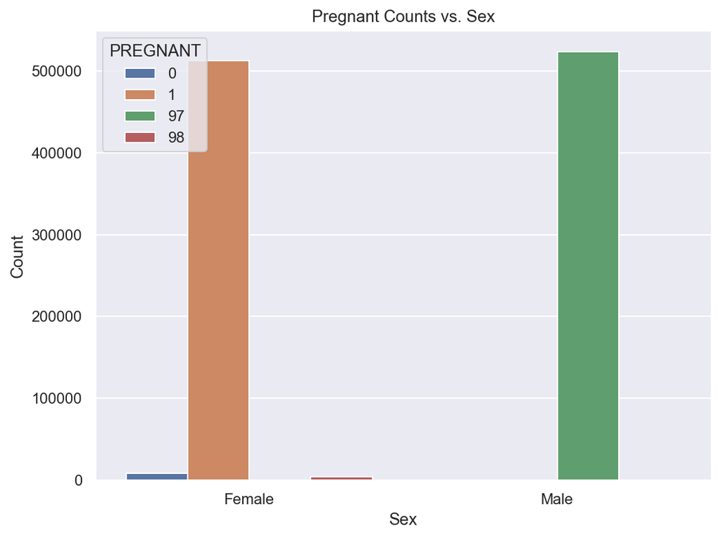

```python
ax, fig = plt.subplots(figsize=(8,6))
ax = sns.countplot(x=df['SEX'], hue = df['PREGNANT'])
ax.set_title("Pregnant Counts vs. Sex")
ax.set_xlabel("Sex")
ax.set_ylabel("Count")
ax.set_xticklabels(['Female', 'Male'])
plt.show()
```

While trying to drop missing values, I noticed that dropping the missing values in the **PREGNANT** column was leaving only the value of 0 in the **SEX** column. Upon some investigation, I realized that it's because for men, the **PREGNANT** column value is always 97. Since the missing value for women is always 98, we can safely change all 97's to 0's. Therefore, I will change this value to 0 to avoid this affecting our analysis. Then, I will drop the missing values.

```python
# change the values of 97 in the pregnant column to 0
df['PREGNANT'] = df['PREGNANT'].apply(lambda x : 0 if x == 97 else x)

# dropping missing values (97,98,99)
columns = ['SEX', 'PREGNANT', 'OBESITY', 'TOBACCO', 'PNEUMONIA', 'DIABETES', 'COPD', 'ASTHMA',\
     'IMMSUPR', 'HYPERTENSION', 'CARDIOVASCULAR', 'RENAL_CHRONIC']
for column in columns:
    df = df[(df[column] == 0) | (df[column] == 1)]
```

## Part 4 : Exploratory Data Analysis

### Showing Correlations using Heapmap

Since I'm interested in what factors affect the mortality rate of covid patients, I will look at the correlation between the target variable and the other columns. I will also look at the correlation between the other columns to see if there are any columns that are highly correlated with each other.

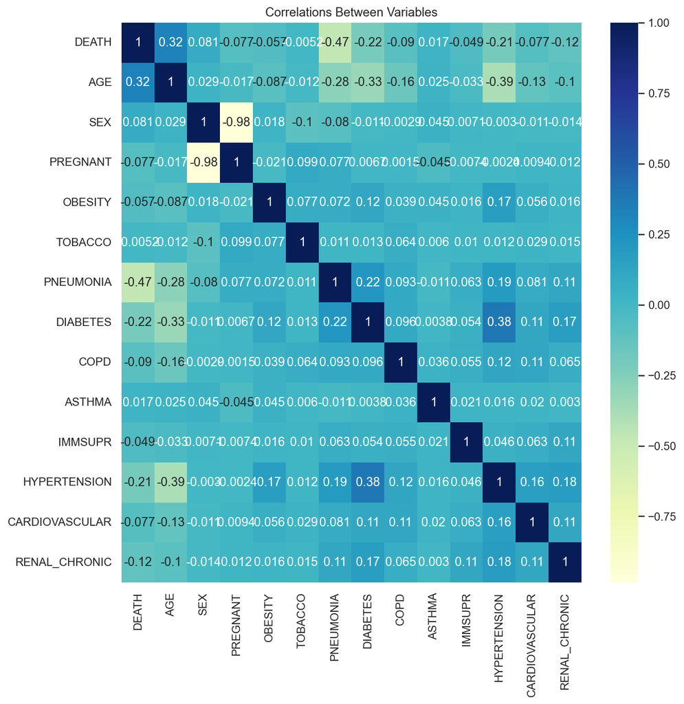

```python
# creating a heatmap to get a better idea of the correlation between the variables
ax = sns.heatmap(df.corr(), cmap="YlGnBu", annot=True)
sns.set(rc={'figure.figsize':(10,10)})
ax.set_title("Correlations Between Variables")
plt.show()
```

From the heatmap above, we can see that sex and pregnancy are highly correlated, which is obvious. but I want to see if being pregnant increases the risk of mortality of covid patients so I'll be keeping that column in as well.  
When it comes to the variables that are highly correlated with the target variable (death), they are **age**, **pneumonia**, **diabetes**, and **hypertension**.

### Barplot : Mortality Rate vs. Other Variables

First of all, let's see which sex is more likely to die from covid. Of course this won't be unbiased, as there can be other variables affecting the result. However, I think it's still interesting to see. To make sure it isn't the age that is affecting the result, I will check the age distribution between men and women in the dataset.

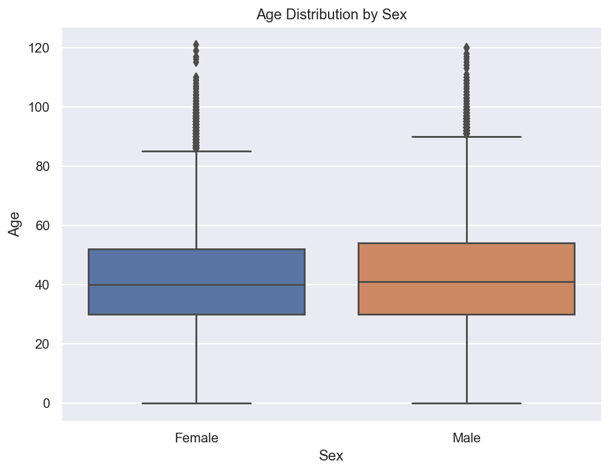

```python
fig, ax = plt.subplots(figsize=(8,6))
ax = sns.boxplot(data=df, x='SEX', y='AGE')
ax.set_title("Age Distribution by Sex")

ax.set_xlabel("Sex")
ax.set_xticklabels(['Female', 'Male'])
ax.set_ylabel("Age")
```

Looking at the boxplot, it seems like the age distributions between men and women are pretty much identical. Now, I can compare the mortaility rates between the two sexes.

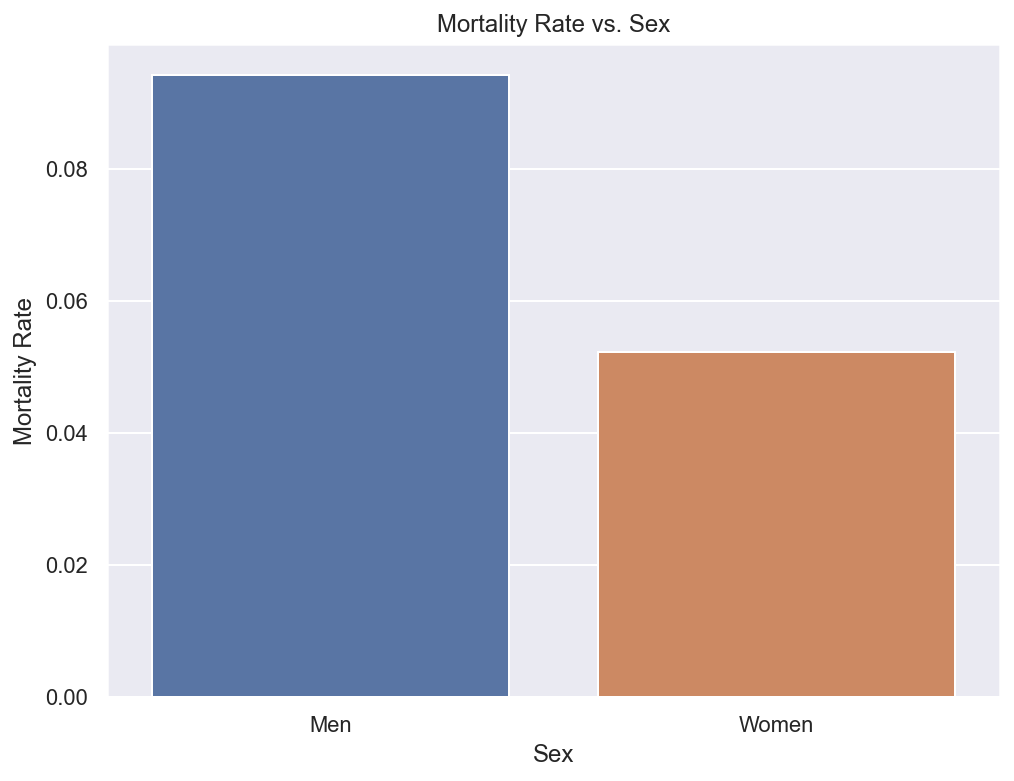

```python
# x-axis and y-axis
sex = ['Men', 'Women']
death_rates = []

# appending death rates for men and women separately
df_men = df[df['SEX'] == 1]
df_women = df[df['SEX'] == 0]
death_rates.append(len(df_men[df_men['DEATH'] == 1].index) / len(df_men.index))
death_rates.append(len(df_women[df_women['DEATH'] == 1].index) / len(df_women.index))

# bar plot
fig, ax = plt.subplots(figsize=(8,6))
ax = sns.barplot(x=sex, y=death_rates)
ax.set_title("Mortality Rate vs. Sex")
ax.set_xlabel("Sex")
ax.set_ylabel("Mortality Rate")
plt.show()
```

It seems like men are more likely to die from covid compared to women. For now, this doesn't tell us much since we haven't analyzed other factors yet. Before I move on to anlayzing the health condition factors, I want to create a plot showing how mortality rates vary depending on the age group.

```python
print(max(df['AGE']))
```

```
121
```

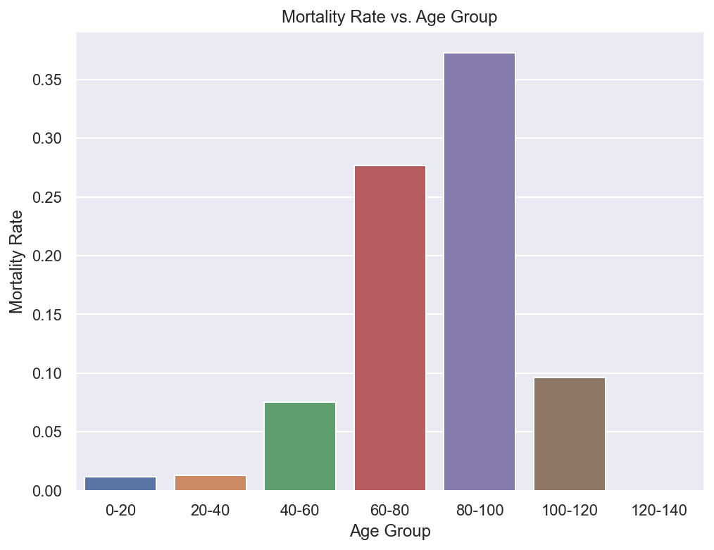

```python
# since max age = 121, create a bin from 0 - 140 and use pandas cut function to create
# a new column
bins = [0, 20, 40, 60, 80, 100, 120, 140]
age_groups = ['0-20', '20-40', '40-60', '60-80', '80-100', '100-120', '120-140']
df['AGE_GROUP'] = pd.cut(df['AGE'], bins=bins, labels=age_groups, include_lowest=True)

# list of mortality rates depending on the age group
death_age = []
for age_group in age_groups:
    df_age = df[df['AGE_GROUP'] == age_group]
    death_age.append(len(df_age[df_age['DEATH'] == 1].index) / len(df_age.index))

# bar plot
fig, ax = plt.subplots(figsize=(8,6))
ax = sns.barplot(x=age_groups, y=death_age)
ax.set_title("Mortality Rate vs. Age Group")
ax.set_xlabel("Age Group")
ax.set_ylabel("Mortality Rate")
plt.show()
```

Rather obviously, the mortality rate increases as the age increases. However, the patients who are over the age of 100 seem to have lower mortality rates, which may be due to the fact that having lived that long means they've taken good care of their health in general to begin with.  
Now, I will create a plot showing the mortality rate of covid patients depending on their age and health conditions. Since the mortality rate for those over the age of 120 is 0 (probably because there's so few of them), I will exclude that group from the plot moving forward.

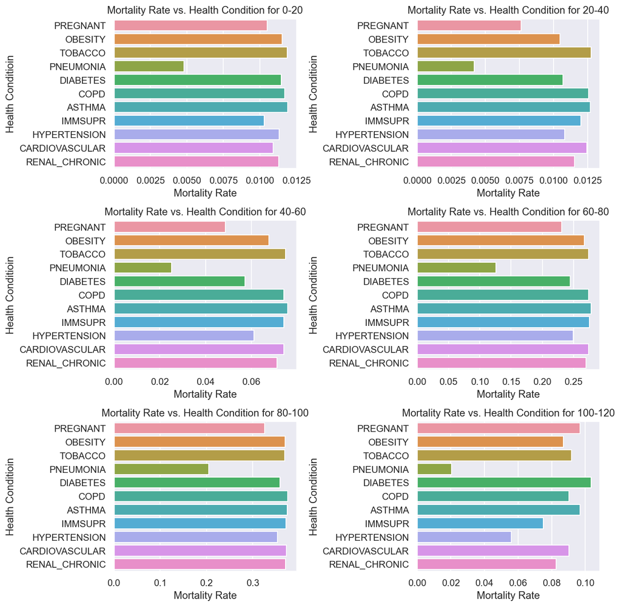

```python
# exclude death since it's the target;
# exclude age and sex since we already examined them
cols.pop(cols.index('DEATH'))
cols.pop(cols.index('AGE'))
cols.pop(cols.index('SEX'))

fig, axs = plt.subplots(nrows=3,ncols=2, figsize=(10,10))
row, col = 0, 0 # index values for the grid

age_groups = ['0-20', '20-40', '40-60', '60-80', '80-100', '100-120']
for age_group in age_groups:
    df_age = df[df['AGE_GROUP'] == age_group]

    death_rates = []
    for column in cols:
        df_column = df_age[df_age[column] == 1]
        death_rates.append \
        (len(df_column[df_column['DEATH'] == 1].index) / len(df_column.index))

    # bar plot
    ax = sns.barplot(y=cols, x=death_rates, ax=axs[row][col])
    ax.set_title(f"Mortality Rate vs. Health Condition for {age_group}")
    ax.set_xlabel("Mortality Rate")
    ax.set_ylabel("Health Conditioin")

    # setting index values for the grid
    if col == 1:
        row += 1
        col = 0
    else:
        col += 1

fig.tight_layout()
plt.show()
```

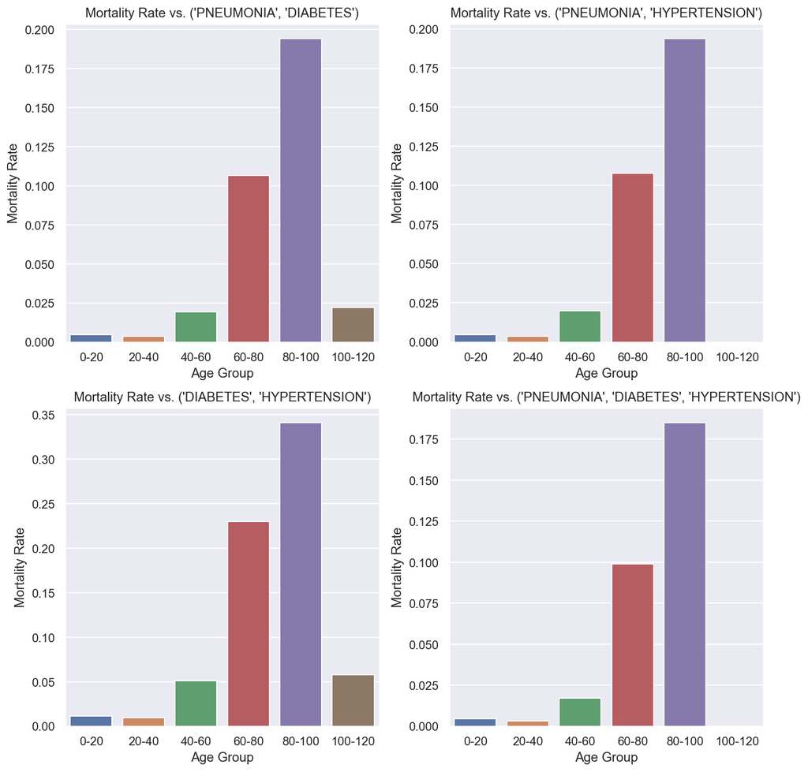

```python
var_list = ['PNEUMONIA', 'DIABETES', 'HYPERTENSION'] # list of variables to combine

def combinations(var_list):
    list = []
    for L in range(2, len(var_list) + 1):
        list.extend(itertools.combinations(var_list, L))
    return list

comb_list = combinations(var_list) # list of combinations

fig, axs = plt.subplots(nrows=2,ncols=2)
row, col = 0, 0 # index values for the grid

# loop through each combination and create a bar plot
for comb in comb_list:
    df_cond = df.copy()
    for i in range(len(comb)):
        df_cond = df_cond[df_cond[comb[i]] == 1]

    death_cond = []
    for age_group in age_groups:
        df_age = df_cond[df_cond['AGE_GROUP'] == age_group]
        death_cond.append(len(df_age[df_age['DEATH'] == 1].index) / len(df_age.index))

    # bar plot
    ax = sns.barplot(x=age_groups, y=death_cond, ax=axs[row][col])
    ax.set_title(f"Mortality Rate vs. {comb}")
    ax.set_xlabel("Age Group")
    ax.set_ylabel("Mortality Rate")

    # setting index values for the grid
    if col == 1:
        row += 1
        col = 0
    else:
        col += 1

fig.tight_layout()
plt.show()
```

We can see that the mortality rates differ, but again, since age is the largest factor affecting the mortality rate, it's hard to compare the mortality rates between the combinations. Therefore, I will create a plot comparing the mortality rates between the combinations for each of the age groups. Since the age group (120, 140) has 0 mortality rate in the plots above, I will exclude that age group from the plots below.

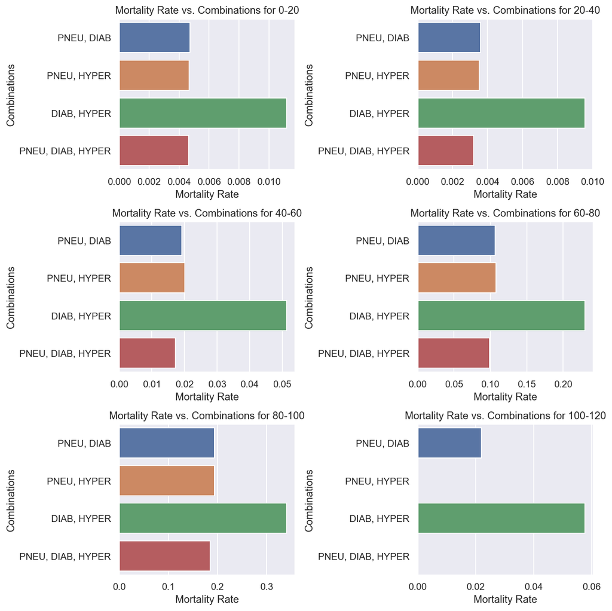

```python
# since the names are long, I will abbreviate them
subsets = ['PNEU, DIAB', 'PNEU, HYPER', 'DIAB, HYPER', 'PNEU, DIAB, HYPER']
age_groups = ['0-20', '20-40', '40-60', '60-80', '80-100', '100-120']
var_list = ['PNEUMONIA', 'DIABETES', 'HYPERTENSION'] # list of variables to combine
comb_list = combinations(var_list) # list of combinations

fig2, axs2 = plt.subplots(nrows=3,ncols=2, figsize=(10,10))
row, col = 0, 0 # index values for the grid

for age_group in age_groups:
    df_age = df[df['AGE_GROUP'] == age_group]

    death_age_cond = []
    for comb in comb_list:
        df_ac = df_age.copy()
        for i in range(len(comb)):
            df_ac = df_ac[df_ac[comb[i]] == 1] # conditioning the dataset
        death_count = len(df_ac[df_ac['DEATH'] == 1].index)
        death_age_cond.append(death_count / len(df_ac.index))

    # bar plot
    ax = sns.barplot(y=subsets, x=death_age_cond, ax=axs2[row][col])
    ax.set_title(f"Mortality Rate vs. Combinations for {age_group}")
    ax.set_xlabel("Mortality Rate")
    ax.set_ylabel("Combinations")
    ax.set_yticklabels(subsets)

    # setting index values for the grid
    if col == 1:
        row += 1
        col = 0
    else:
        col += 1

fig2.tight_layout()
plt.show()
```

As we can clearly see, the combination of **diabetes** and **hypertension** seems to cause the highest mortaliry rate among covid patients. However, interestingly, the mortality rate isn't significantly higher compared to when I examined each health condition individually. Regardless, by examining the correlation values we obtained for the 4 variables (age, pneumonia, diabetes, hypertension) and the result obtained from the plots above, we can conclude that older covid patients who have diabetes and hypertension are at the highest risk of dying from covid.

## Part 5 : Hypothesis Testing

**Hypothesis : The health condition variables are not correlated with the moratlity rate of covid patients.**

To test this hypothesis, I will use Pearson's correlation coefficient. The null hypothesis is that the correlation coefficient is 0, which means that there is no correlation between the variables. The alternative hypothesis is that the correlation coefficient is not 0, which means that there is a correlation between the variables.

```python
for col in cols:
    corr, p = pearsonr(df[col], df['DEATH'])

    if p < 0.05:
        print(f"{col} - Correlation: {corr}, p-value: {p}")
```

```
PREGNANT - Correlation: -0.07685065808419557, p-value: 0.0
OBESITY - Correlation: -0.05651224850606834, p-value: 0.0
TOBACCO - Correlation: -0.005199646460595949, p-value: 1.4343233753842935e-07
PNEUMONIA - Correlation: -0.47081483420141984, p-value: 0.0
DIABETES - Correlation: -0.2171971270179021, p-value: 0.0
COPD - Correlation: -0.08988532365020493, p-value: 0.0
ASTHMA - Correlation: 0.01734857124446184, p-value: 5.56286939801154e-69
IMMSUPR - Correlation: -0.04930898750020367, p-value: 0.0
HYPERTENSION - Correlation: -0.2052520944882401, p-value: 0.0
CARDIOVASCULAR - Correlation: -0.07681276484639363, p-value: 0.0
RENAL_CHRONIC - Correlation: -0.11946382716657909, p-value: 0.0
```

Because all of the p-values are less than 0.05, the correlations are statistically significant. Therefore, we can reject the null hypothesis and conclude that there is a correlation between each of the health condition variables and the mortality rate of covid patients.

## Part 6 : Training the Machine Learning Model

For the machine learning model that predicts the mortality of covid patients, I will be using two different algorithms: **Logistic Regression** and **Random Forest**. I will be using the **accuracy**, **precision** and **recall** metrics to evaluate the performance of the models. I will also be using **10-fold-cross-validation** to evaluate the performance of the models.

### Logistic Regression

```python
# dropping age group as it's not needed anymore
df.drop(columns=['AGE_GROUP'], inplace=True)

X = df.iloc[:,1:] # select all columns but the first one
y = df.iloc[:,0] # select just the first column (target)

# scale the age column
mm_scaler = MinMaxScaler()
X = pd.DataFrame(mm_scaler.fit_transform(X))

# dropping na values and running Logistic Regression
df.dropna(inplace=True)
log = LogisticRegression()
log.fit(X, y)

# 10-fold cross validation for accuracy, precision, and recall
ten_fold = KFold(n_splits=10, shuffle=True, random_state=1)
acc_scores = cross_val_score(log, X, y, scoring='accuracy', cv=ten_fold)
pre_scores = cross_val_score(log, X, y, scoring='precision', cv=ten_fold)
rec_scores = cross_val_score(log, X, y, scoring='recall', cv=ten_fold)
print(f"Accuracy: {mean(acc_scores)}")
print(f"Precision: {mean(pre_scores)}")
print(f"Recall: {mean(rec_scores)}")
```

```
Accuracy: 0.9326663073407501
Precision: 0.5685284504762107
Recall: 0.33227884886401965
```

We can see that the accuracy is very high but precision and recall are extremely low. This is probably because the dataset is imbalanced. Let's count the number of 0's and 1's in the target variable.

```python
# counting the number of deaths and alive
print(f"Dead : {len(df[df['DEATH'] == 1].index)}")
print(f"Alive : {len(df[df['DEATH'] == 0].index)}")
```

```
Dead : 74925
Alive : 948723
```

As expected, there are way more 0's than 1's, which is causing the problem. Initially, I tried using oversampling method but since it was taking too long, I will try the undersampling method to resample the data.

```python
# undersampling the majority class
under = RandomUnderSampler(sampling_strategy=0.5)
X, y = under.fit_resample(X, y)

# logistic regression and 10-fold cross validation
log = LogisticRegression()
log.fit(X, y)

acc_scores = cross_val_score(log, X, y, scoring='accuracy', cv=ten_fold)
pre_scores = cross_val_score(log, X, y, scoring='precision', cv=ten_fold)
rec_scores = cross_val_score(log, X, y, scoring='recall', cv=ten_fold)
print(f"Accuracy: {mean(acc_scores)}")
print(f"Precision: {mean(pre_scores)}")
print(f"Recall: {mean(rec_scores)}")
```

```
Accuracy: 0.8565988428431887
Precision: 0.8090877115080632
Recall: 0.7457622529366641
```

### Random Forest

After undersampling, the performance of the model has improved significantly. However, just to see if a different algorithm performs better, I will try using **random forest** algorithm this time to see if it achieves better results.  
First, I will use grid search to tune the hyperparameters of the model.

```python
# undersampling
under = RandomUnderSampler(sampling_strategy=0.5)
X_res, y_res = under.fit_resample(X, y)

# grid search to find out the best hyperparameters
max_depth = [2, 8, 16]
n_estimators = [64, 128, 256]
param_grid = dict(max_depth=max_depth, n_estimators=n_estimators)

dfrst = RandomForestClassifier(n_estimators=n_estimators, max_depth=max_depth)
grid = GridSearchCV(estimator=dfrst, param_grid=param_grid, cv=10)
grid_results = grid.fit(X_res, y_res)

print(f"{grid_results.best_params_}")
```

```
{'max_depth': 8, 'n_estimators': 128}
```

```python
# random forest with the best hyperparameters
forest = RandomForestClassifier(criterion='gini', max_depth=8, n_estimators=128, random_state=1)
fr = forest.fit(X_res, y_res)

# 10-fold cross validation to find out the accuracy, precision, and recall
acc_scores = cross_val_score(fr, X_res, y_res, scoring='accuracy', cv=ten_fold)
pre_scores = cross_val_score(fr, X_res, y_res, scoring='precision', cv=ten_fold)
rec_scores = cross_val_score(fr, X_res, y_res, scoring='recall', cv=ten_fold)
print(f"Accuracy: {mean(acc_scores)}")
print(f"Precision: {mean(pre_scores)}")
print(f"Recall: {mean(rec_scores)}")
```

```
Accuracy: 0.8578534034512043
Precision: 0.7951704239395262
Recall: 0.7726069620794511
```

Using the hyperparameters obtained by grid search, I trained the model and improved the overall performance of the model. The result is similar to that of the logistic regression model after undersampling, but it's still a huge improvement from the original model.